# PSYC800_Unit1Project

## **Overview**

Topic Area: Social Sciences

Specific subtopic: Perception of Choice within Marriage among North Americans vs South Asian Indians

This project extends cultural psychological research on construing actions as choices to the study of relationships. In an experiment, we manipulated perceived choice in marriage and observed its effect on perceived choice present in the arrangement and people’s predictions (through their perceptions) about marital well-being, marriage longevity, and familial happiness. This was interesting as we recruited both South Asian Indian and North American sample (Indian N = 109, American N = 102). Participants read a vignette of a family arranging their offspring's marriage in which either the couple chose their marital partners (choice condition) or their family chose their marital partners for them (no-choice condition). Analysis of the differences in people’s perceptions of marriage through the lens of their Nationalities was fascinating.

## **Wrangling**

The data source is a study we ran in February 2023. The study was conducted through a Qualtrics survey and the dataset was designed accordingly. It was easy to export the Qualtrics data as an Excel file, check for discrepancies, sort them, and then export the dataset as a CSV. Then the data was imported into R (as below). I chose to import the full dataset and the columns with NA values were not utilized in my analysis for this project. Next, I ran some correlations on the variables that could be grouped together for analysis.

```r
library(readr)
library(tibble)
library(dplyr)
library(tidyverse)
cm_data <- tibble(
  read_csv("Choice_Marriage_03022023n.csv"))
cm_data[, colSums(is.na(cm_data)) < nrow(cm_data)]
```

```
# A tibble: 211 × 104
      ID Nationality condi…¹   gen   age ethnR…² ethnR…³ homet…⁴ situa…⁵ choic…⁶
   <dbl>       <dbl>   <dbl> <dbl> <dbl>   <dbl> <chr>   <chr>   <chr>     <dbl>
 1    19           1      -1     1    48       2 <NA>    <NA>    A fami…       4
 2    60           1      -1     1    35       6 <NA>    <NA>    Two ne…       4
 3   109          -1      -1     1    40      NA <NA>    Chandi… Family…       4
 4   119          -1      -1     1    26      NA <NA>    Hydera… Actual…       4
 5   129          -1      -1     1    32      NA <NA>    Hydera… Weddin…       4
 6   153          -1      -1     1    40      NA <NA>    Nellore Marria…       4
 7   161          -1      -1     1    45      NA <NA>    Banglo… Absolu…       4
 8   199          -1      -1     1    20      NA <NA>    Ernaku… A Fami…       4
 9   207          -1      -1     1    50      NA <NA>    Visakh… It is …       4
10    12           1       1     0    34       6 <NA>    <NA>    A fami…       4
# … with 201 more rows, 94 more variables: choice_family <dbl>, tog_2 <dbl>,
#   suc_2 <dbl>, obligation_2 <dbl>, devotion_2 <dbl>, love_2 <dbl>,
#   compromise_2 <dbl>, reliance_2 <dbl>, connection_2 <dbl>, loyalty_2 <dbl>,
#   contentment_2 <dbl>, harmony_2 <dbl>, conflict_2 <dbl>, conflict_r_2 <dbl>,
#   dedication_2 <dbl>, happiness_2 <dbl>, sacrifice_2 <dbl>, lust_2 <dbl>,
#   commitment_2 <dbl>, satisfaction_2 <dbl>, passion_2 <dbl>, trust_2 <dbl>,
#   closeness_2 <dbl>, friendship_2 <dbl>, understanding_2 <dbl>, …
```

**Click Here to See More**

```r
print(cor(cm_data[, c('satisfaction_2','happiness_2','contentment_2')]))
```

```
               satisfaction_2 happiness_2 contentment_2
satisfaction_2      1.0000000   0.8066281     0.6150926
happiness_2         0.8066281   1.0000000     0.6163296
contentment_2       0.6150926   0.6163296     1.0000000
```

```r
print(cor(cm_data[, c('commitment_2','dedication_2','devotion_2')]))
```

```
             commitment_2 dedication_2 devotion_2
commitment_2            1           NA         NA
dedication_2           NA    1.0000000  0.4957605
devotion_2             NA    0.4957605  1.0000000
```

```r
print(cor(cm_data[, c('intimacy_2','closeness_2','connection_2')]))
```

```
             intimacy_2 closeness_2 connection_2
intimacy_2    1.0000000   0.7044784    0.6344027
closeness_2   0.7044784   1.0000000    0.6822435
connection_2  0.6344027   0.6822435    1.0000000
```

```r
print(cor(cm_data[, c('trust_2','reliance_2','dependability_2')]))
```

```
                trust_2 reliance_2 dependability_2
trust_2               1         NA              NA
reliance_2           NA  1.0000000       0.4389191
dependability_2      NA  0.4389191       1.0000000
```

```r
print(cor(cm_data[, c('passion_2','lust_2','desire_2')]))
```

```
          passion_2    lust_2  desire_2
passion_2 1.0000000 0.4186075 0.6583308
lust_2    0.4186075 1.0000000 0.4255078
desire_2  0.6583308 0.4255078 1.0000000
```

```r
print(cor(cm_data[, c('obligation_2','compromise_2','sacrifice_2')]))
```

```
             obligation_2 compromise_2 sacrifice_2
obligation_2    1.0000000    0.1594275   0.1725508
compromise_2    0.1594275    1.0000000   0.5150959
sacrifice_2     0.1725508    0.5150959   1.0000000
```

```r
print(cor(cm_data[, c('obligation_2','compromise_2','sacrifice_2')]))
```

```
             obligation_2 compromise_2 sacrifice_2
obligation_2    1.0000000    0.1594275   0.1725508
compromise_2    0.1594275    1.0000000   0.5150959
sacrifice_2     0.1725508    0.5150959   1.0000000
```

```r
print(cor(cm_data[, c('love_2','friendship_2','adoration_2')]))
```

```
                love_2 friendship_2 adoration_2
love_2       1.0000000    0.6323381   0.6004546
friendship_2 0.6323381    1.0000000   0.6103897
adoration_2  0.6004546    0.6103897   1.0000000
```

```r
print(cor(cm_data[, c('trust_2','desire_2','dependability_2')]))
```

```
                trust_2  desire_2 dependability_2
trust_2               1        NA              NA
desire_2             NA 1.0000000       0.5336591
dependability_2      NA 0.5336591       1.0000000
```

```r
print(cor(cm_data[, c('loyalty_2','respect_2','understanding_2')]))
```

```
                loyalty_2 respect_2 understanding_2
loyalty_2       1.0000000 0.5846931       0.5578349
respect_2       0.5846931 1.0000000       0.7460458
understanding_2 0.5578349 0.7460458       1.0000000
```

```r
print(cor(cm_data[, c('satisfaction_10','happiness_10','contentment_10')]))
```

```
                satisfaction_10 happiness_10 contentment_10
satisfaction_10        1.000000     0.780883       0.676232
happiness_10           0.780883     1.000000       0.673917
contentment_10         0.676232     0.673917       1.000000
```

```r
print(cor(cm_data[, c('commitment_10','dedication_10','devotion_10')]))
```

```
              commitment_10 dedication_10 devotion_10
commitment_10     1.0000000      0.663276   0.4676684
dedication_10     0.6632760      1.000000   0.6004560
devotion_10       0.4676684      0.600456   1.0000000
```

```r
print(cor(cm_data[, c('intimacy_10','closeness_10','connection_10')]))
```

```
              intimacy_10 closeness_10 connection_10
intimacy_10     1.0000000    0.6638500     0.6230179
closeness_10    0.6638500    1.0000000     0.7187318
connection_10   0.6230179    0.7187318     1.0000000
```

```r
print(cor(cm_data[, c('trust_10','reliance_10','dependability_10')]))
```

```
                  trust_10 reliance_10 dependability_10
trust_10         1.0000000   0.4806705        0.5750885
reliance_10      0.4806705   1.0000000        0.6357980
dependability_10 0.5750885   0.6357980        1.0000000
```

```r
print(cor(cm_data[, c('passion_10','lust_10','desire_10')]))
```

```
           passion_10   lust_10 desire_10
passion_10  1.0000000 0.6030533 0.7093785
lust_10     0.6030533 1.0000000 0.5873412
desire_10   0.7093785 0.5873412 1.0000000
```

```r
print(cor(cm_data[, c('obligation_10','compromise_10','sacrifice_10')]))
```

```
              obligation_10 compromise_10 sacrifice_10
obligation_10     1.0000000     0.3748826    0.3177795
compromise_10     0.3748826     1.0000000    0.5235029
sacrifice_10      0.3177795     0.5235029    1.0000000
```

```r
print(cor(cm_data[, c('obligation_10','compromise_10','sacrifice_10')]))
```

```
              obligation_10 compromise_10 sacrifice_10
obligation_10     1.0000000     0.3748826    0.3177795
compromise_10     0.3748826     1.0000000    0.5235029
sacrifice_10      0.3177795     0.5235029    1.0000000
```

```r
print(cor(cm_data[, c('love_10','friendship_10','adoration_10')]))
```

```
                love_10 friendship_10 adoration_10
love_10       1.0000000     0.7052502    0.6585780
friendship_10 0.7052502     1.0000000    0.6379981
adoration_10  0.6585780     0.6379981    1.0000000
```

```r
print(cor(cm_data[, c('trust_10','desire_10','dependability_10')]))
```

```
                  trust_10 desire_10 dependability_10
trust_10         1.0000000 0.5204580        0.5750885
desire_10        0.5204580 1.0000000        0.5083724
dependability_10 0.5750885 0.5083724        1.0000000
```

```r
print(cor(cm_data[, c('loyalty_10','respect_10','understanding_10')]))
```

```
                 loyalty_10 respect_10 understanding_10
loyalty_10        1.0000000  0.7038559        0.7234727
respect_10        0.7038559  1.0000000        0.7707203
understanding_10  0.7234727  0.7707203        1.0000000
```

*Variables in Wrangled the dataset:*

Nationality (categorical): 1 (American), -1 (Indian)

Condition (categorical) : 1(More choice in Marriage), -1 (Less/No choice in Marriage)

Gen (gender, categorical): 0 (Male), 1 (Female)

choice_couple (categorical): Perceived amount of choice the couple had in their marriage (0= No choice, 4= A of choice)

choice_family(categorical): Perceived amount of choice the family had in the couple’s marriage (0= No choice, 4= A of choice)

I further utilized the correlations above to mutate variables into one variable for overall satisfaction, love, intimacy, and respect in the marriage after 2 years and 10 years respectively. I further filtered them for American nationality oriented participants.

o_satisfaction_2 : Predicted (by participants) overall satisfaction among the couple in the marriage after 2 years

o_love_2: Predicted (by participants) overall love among the couple in the marriage after 2 years

o_intimacy_2: Predicted (by participants) overall intimacy among the couple in the marriage after 2 years

o_respect_2: Predicted (by participants) overall respect among the couple in the marriage after 2 years

(likewise were the variables for predicted (by participants) overall satisfaction, love, intimacy, and respect, among the couple in the marriage after 10 years)

```r
 x<-
   cm_data |>
   arrange(desc(ID)) |>
   mutate(gen = factor(gen, levels = c(0, 1),
                                 labels = c("Male", "Female"))) |>
   mutate(
          o_satisfaction_2 = satisfaction_2 + happiness_2 + contentment_2,
          o_love_2 = love_2 + friendship_2 + adoration_2,
          o_intimacy_2 = intimacy_2 + closeness_2 + connection_2,
          o_respect_2 = loyalty_2 + respect_2 + understanding_2,

          o_satisfaction_10 = satisfaction_10 + happiness_10 + contentment_10,
          o_love_10 = love_10 + friendship_10 + adoration_10,
          o_intimacy_10 = intimacy_10 + closeness_10 + connection_10,
          o_respect_10 = loyalty_10 + respect_10 + understanding_10) |>
   select (Nationality, gen, choice_couple, choice_family, o_satisfaction_2, o_love_2, o_intimacy_2, o_respect_2, o_satisfaction_10, o_love_10, o_intimacy_10, o_respect_10) |>
   filter(Nationality == 1) |>
   print()
```

```
# A tibble: 102 × 12
   Natio…¹ gen   choic…² choic…³ o_sat…⁴ o_lov…⁵ o_int…⁶ o_res…⁷ o_sat…⁸ o_lov…⁹
     <dbl> <fct>   <dbl>   <dbl>   <dbl>   <dbl>   <dbl>   <dbl>   <dbl>   <dbl>
 1       1 Male        1       3       3       2       2       3       5       2
 2       1 Male        0       4       3       3       1       5       0       0
 3       1 Fema…       4       2      12      11      12      12      12      12
 4       1 Male        1       3       3       4       5       5       0       0
 5       1 Male        3       3       9       8       8       7       8       7
 6       1 Male        3       1       6       7       7       7       6       6
 7       1 Fema…       2       3      11       9      10       7      10       9
 8       1 Fema…       3       4      12      11       9      11      10       9
 9       1 Male        3       3      10      10       9       9      10      11
10       1 Fema…       1       2       5       4       4       7       1       5
# … with 92 more rows, 2 more variables: o_intimacy_10 <dbl>,
#   o_respect_10 <dbl>, and abbreviated variable names ¹Nationality,
#   ²choice_couple, ³choice_family, ⁴o_satisfaction_2, ⁵o_love_2,
#   ⁶o_intimacy_2, ⁷o_respect_2, ⁸o_satisfaction_10, ⁹o_love_10
```

## **Visualizations**

**Figure 1 and Figure 2**

I wanted to create two plots to compare the American participants’ predictions about couple’s satisfaction (by gender), when they perceived an amount of choice the couple had in the marriage, in 2 vs 10 years. I first ran a multiple regression with overall satisfaction as the DV and choice among couple and participant gender as the IVs.

**Click Here to See More**

```r
y <- lm(o_satisfaction_2 ~ choice_couple + gen, data = x)
z <- lm(o_satisfaction_10 ~ choice_couple + gen, data = x)
library(parameters)
model_parameters(y)
```

```
Parameter     | Coefficient |   SE |        95% CI | t(99) |      p
-------------------------------------------------------------------
(Intercept)   |        3.02 | 0.56 | [ 1.91, 4.13] |  5.40 | < .001
choice couple |        1.56 | 0.19 | [ 1.18, 1.94] |  8.19 | < .001
gen [Female]  |        0.74 | 0.44 | [-0.14, 1.62] |  1.68 | 0.097
```

```
Uncertainty intervals (equal-tailed) and p-values (two-tailed) computed
  using a Wald t-distribution approximation.
```

```r
model_parameters(z)
```

```
Parameter     | Coefficient |   SE |       95% CI | t(99) |      p
------------------------------------------------------------------
(Intercept)   |        2.05 | 0.62 | [0.82, 3.28] |  3.31 | 0.001
choice couple |        1.60 | 0.21 | [1.18, 2.02] |  7.57 | < .001
gen [Female]  |        1.27 | 0.49 | [0.30, 2.25] |  2.59 | 0.011
```

```
Uncertainty intervals (equal-tailed) and p-values (two-tailed) computed
  using a Wald t-distribution approximation.
```

I chose the aesthetic mappings to reflect ‘Perceived Choice in Marriage among Couple’ on the x-axis and ‘Predicted Overall Satisfaction in Marriage after 2yrs’ (and/or 10 yrs) on y-axis. I used geom_jitter and geom_smooth to detect random variations and further to analyse the trends (through trend lines created by geom_smooth) for each gender.

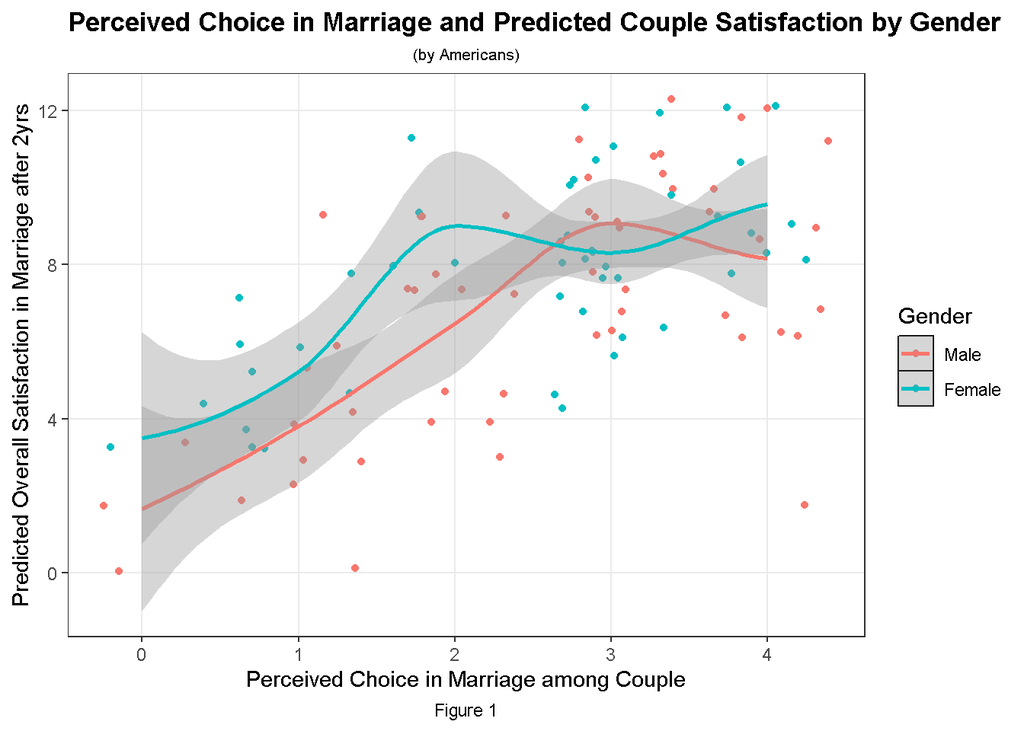

```r
ggplot(y, aes(choice_couple, o_satisfaction_2, color=gen)) +
  geom_jitter() +
  labs(x="Perceived Choice in Marriage among Couple",
       y="Predicted Overall Satisfaction in Marriage after 2yrs",
       color = "Gender",
       title = "Perceived Choice in Marriage and Predicted Couple Satisfaction by Gender",
       subtitle = "(by Americans)",
       caption = "Figure 1")+
  geom_smooth() +
    theme_bw()+
    theme(
    plot.title = element_text(face = "bold"),
    plot.subtitle = element_text(size = 8, hjust = 0.5),
    plot.caption = element_text(hjust = 0.5),
    panel.grid.minor = element_blank(),
    legend.key = element_rect(colour = "black"))
```

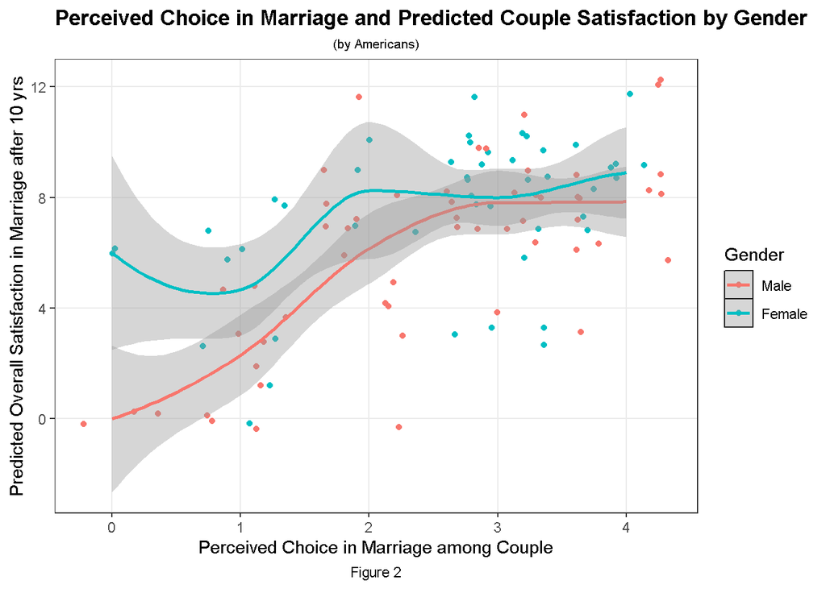

```r
ggplot(z, aes(choice_couple, o_satisfaction_10,color=gen)) +
  geom_jitter() +
  labs(y="Predicted Overall Satisfaction in Marriage after 10 yrs",
       x="Perceived Choice in Marriage among Couple",
       color = "Gender",
       title = "Perceived Choice in Marriage and Predicted Couple Satisfaction by Gender",
       subtitle = "(by Americans)",
       caption = "Figure 2")+
  geom_smooth() +
  theme_bw() +
  theme(panel.grid.minor = element_blank(),
    plot.title = element_text(face = "bold"),
    plot.subtitle = element_text(size = 8, hjust = 0.5),
    plot.caption = element_text(hjust = 0.5),
    legend.key = element_rect(colour = "black"))
```

**Figure 3 and Figure 4**

**Click Here to See More**

```r
a <- lm(o_love_2 ~ choice_family, data = x)
b <- lm(o_love_10 ~ choice_family, data = x)
library(parameters)
model_parameters(a)
```

```
Parameter     | Coefficient |   SE |        95% CI | t(100) |      p
--------------------------------------------------------------------
(Intercept)   |        7.98 | 0.91 | [ 6.18, 9.79] |   8.76 | < .001
choice family |       -0.32 | 0.30 | [-0.91, 0.27] |  -1.08 | 0.281
```

```
Uncertainty intervals (equal-tailed) and p-values (two-tailed) computed
  using a Wald t-distribution approximation.
```

```r
model_parameters(b)
```

```
Parameter     | Coefficient |   SE |        95% CI | t(100) |      p
--------------------------------------------------------------------
(Intercept)   |        7.03 | 1.04 | [ 4.97, 9.09] |   6.77 | < .001
choice family |    3.59e-03 | 0.34 | [-0.67, 0.67] |   0.01 | 0.992
```

```
Uncertainty intervals (equal-tailed) and p-values (two-tailed) computed
  using a Wald t-distribution approximation.
```

I chose the aesthetic mappings to reflect ‘Perceived Choice in Marriage by Family’ on the x-axis and ‘Predicted Overall Love in Marriage after 2yrs’ (and/or 10 yrs) on y-axis. I used geom_smooth and method ‘lm’ to detect what type of association do these variables have.

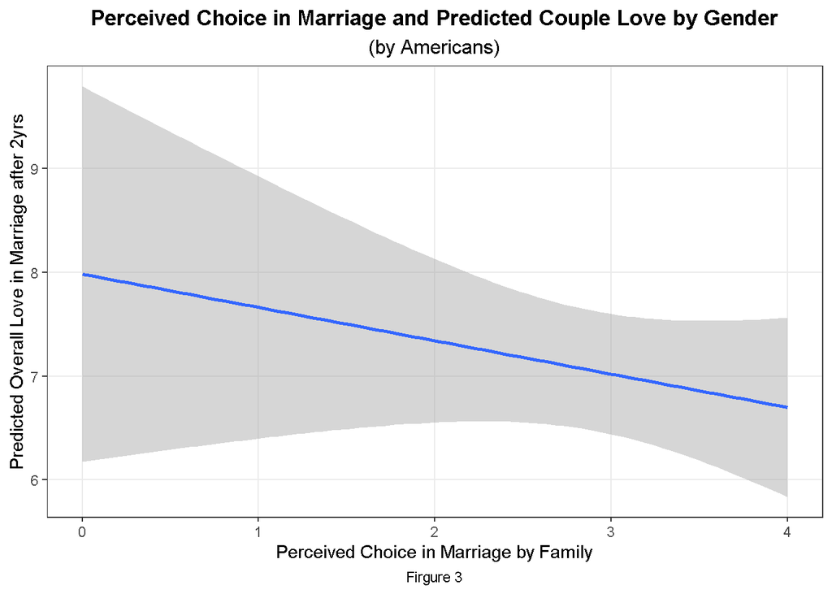

```r
ggplot(a, aes(choice_family, o_love_2)) +
  geom_smooth(method = "lm") +
  labs(x="Perceived Choice in Marriage by Family",
       y="Predicted Overall Love in Marriage after 2yrs",
       title = "Perceived Choice in Marriage and Predicted Couple Love by Gender",
       subtitle = "(by Americans)",
       caption = "Firgure 3")+
  scale_color_manual(values=c("Blue","Yellow")) +
  theme_bw() +
  theme(panel.grid.minor = element_blank(),
        plot.title = element_text(face = "bold", hjust = 0.5),
        plot.subtitle = element_text(size = 12, hjust = 0.5),
        plot.caption = element_text(hjust = 0.5))
```

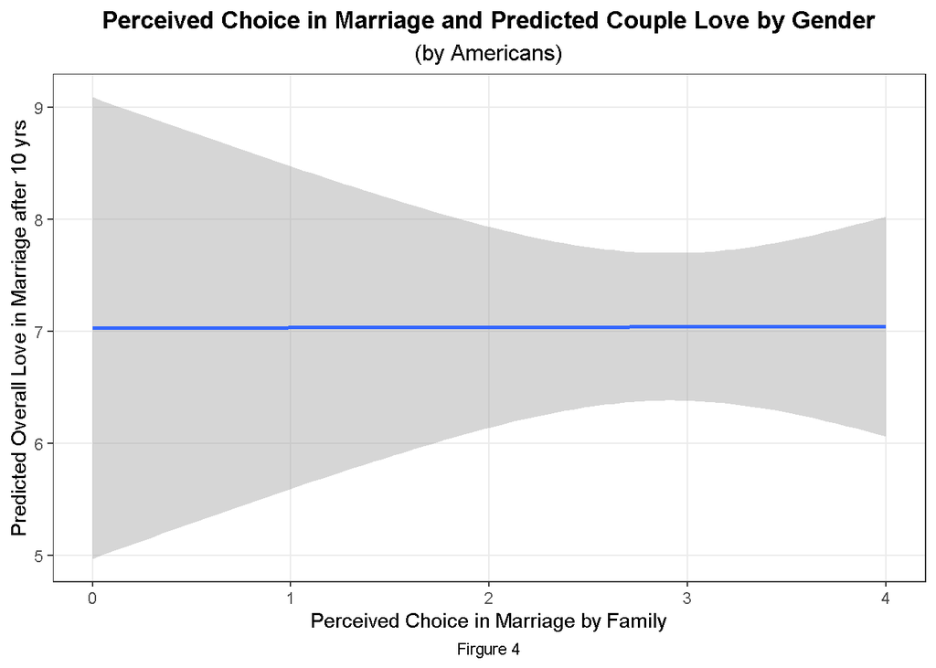

```r
ggplot(b, aes(choice_family, o_love_10)) +
  geom_smooth(method = "lm") +
  labs(y="Predicted Overall Love in Marriage after 10 yrs",
       x="Perceived Choice in Marriage by Family",
       title = "Perceived Choice in Marriage and Predicted Couple Love by Gender",
       subtitle = "(by Americans)",
       caption = "Firgure 4")+
  scale_color_manual(values=c("Blue","Yellow")) +
  theme_bw() +
  theme(panel.grid.minor = element_blank(),
        plot.title = element_text(face = "bold", hjust = 0.5),
        plot.subtitle = element_text(size = 12, hjust = 0.5),
        plot.caption = element_text(hjust = 0.5))
```

**Figure 5 and Figure 6**

In these, I wanted to analyse the data of Indian sample and compare the predicted overall Respect in Marriage in 2 vs 10 years by Gender.

**Click Here to See More**

```r
d<-
   cm_data |>
   mutate(gen = factor(gen, levels = c(0, 1),
                                 labels = c("Male", "Female"))) |>
   mutate(
          o_satisfaction_2 = satisfaction_2 + happiness_2 + contentment_2,
          o_love_2 = love_2 + friendship_2 + adoration_2,
          o_intimacy_2 = intimacy_2 + closeness_2 + connection_2,
          o_respect_2 = loyalty_2 + respect_2 + understanding_2,

          o_satisfaction_10 = satisfaction_10 + happiness_10 + contentment_10,
          o_love_10 = love_10 + friendship_10 + adoration_10,
          o_intimacy_10 = intimacy_10 + closeness_10 + connection_10,
          o_respect_10 = loyalty_10 + respect_10 + understanding_10) |>
   select (Nationality, gen, -choice_couple, -choice_family, o_respect_2, o_respect_10)|>
   filter(Nationality == -1) |>
   print()
```

```
# A tibble: 109 × 4
   Nationality gen    o_respect_2 o_respect_10
         <dbl> <fct>        <dbl>        <dbl>
 1          -1 Female          12           10
 2          -1 Female           9            9
 3          -1 Female          12           12
 4          -1 Female           9            3
 5          -1 Female          10           10
 6          -1 Female           5            3
 7          -1 Female          10            8
 8          -1 Female          12           11
 9          -1 Male            11            9
10          -1 Male             9           10
# … with 99 more rows
```

I chose the aesthetic mappings to reflect ‘Gender’ on the x-axis and ‘Predicted Overall Respect in Marriage after 2yrs’ (and/or 10 yrs) on y-axis. I used geom_bar to create bar plots for each gender and put color variation to depict each Gender.

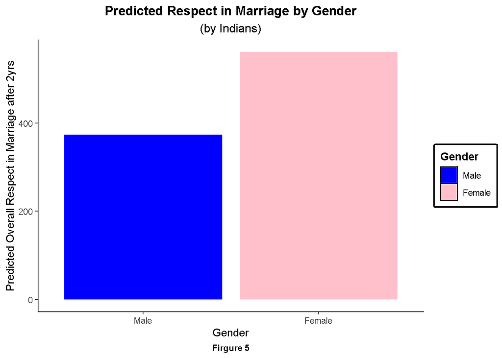

```r
ggplot(d, aes(x=gen, y=o_respect_2, fill=as.factor(gen))) +
  geom_bar(stat = "identity") +
  scale_fill_manual(values = c("blue", "pink"),
                    name = "Gender") +
  labs(x="Gender",
       y="Predicted Overall Respect in Marriage after 2yrs",
       title = "Predicted Respect in Marriage by Gender",
       subtitle = "(by Indians)",
       caption = "Firgure 5") +
  theme_classic() +
  theme(plot.title = element_text(face = "bold", hjust = 0.5),
        plot.subtitle = element_text(size = 12, hjust = 0.5),
        plot.caption = element_text(face = "bold", hjust = 0.5),
        legend.box.background = element_rect(color="black", linewidth=1.5),
        legend.key = element_rect(colour = "black"),
        legend.title = element_text(face = "bold"))
```

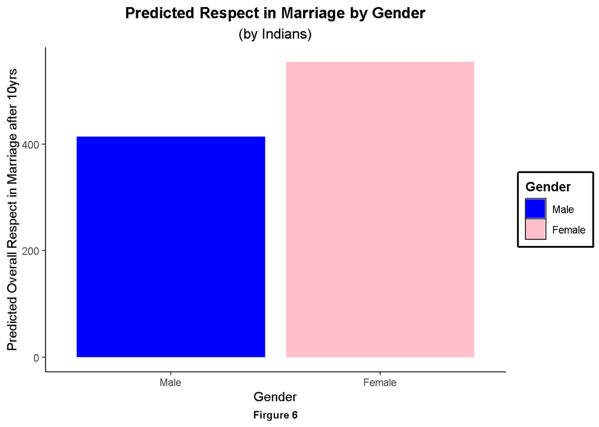

```r
ggplot(d, aes(x=gen, y=o_respect_10, fill=as.factor(gen))) +
  geom_bar(stat = "identity") +
  scale_fill_manual(values = c("blue", "pink"),
                    name = "Gender") +
  labs(x="Gender",
       y="Predicted Overall Respect in Marriage after 10yrs",
       title = "Predicted Respect in Marriage by Gender",
       subtitle = "(by Indians)",
       caption = "Firgure 6") +
  theme_classic() +
  theme(plot.title = element_text(face = "bold", hjust = 0.5),
        plot.subtitle = element_text(size = 12, hjust = 0.5),
        plot.caption = element_text(face = "bold", hjust = 0.5),
        legend.box.background = element_rect(color="black", linewidth=1.5),
        legend.key = element_rect(colour = "black"),
        legend.title = element_text(face = "bold"))
```

## **Conclusions**

*From Figures 3 and 4*

- When Americans perceive that the familial choice in marriage was greater, their predicted level of love in the marriage after 2 years shows a decrease.
- When Americans perceive that the familial choice in marriage was greater, their predicted level of love in the marriage after 10 years remains stable.

*From Figures 5 and 6*

- Predictions of overall respect in marriage in 2 vs 10 years remain greater for Indian females while Indian males predict higher overall respect in marriage after 10 years relative to after 2 years.

## **Retrospective**

About doing data science with real-world data, I learnt that real-world data is often messier, more complex, and less structured. Real-world data sets are large, noisy, and contain numerous missing values and/or outliers. Additionally, real-world data may have data inconsistent data types, or data inaccuracies. Cleaning this data is challenging and requires an understanding of data wrangling techniques.

In contrast, examples from class are usually clean, well-structured, and have been carefully curated to teach specific concepts. Instructors happen to select examples that are more directly focused and easy to work with, so students can focus on learning the underlying principles, tools, and concepts. Examples from class are cleaned and pre-processed before they can be analyzed as opposed to real-world data.

Collecting own data required to firstly have domain-specific knowledge, then plan the data collection process, check ethical considerations, collect data, wrangle data, and further analyse data using specific R functions and codes. Some of the challenges were: it was time consuming to clean data and make it usable for analysis, and learning of relevant data analysis techniques was required.